# **【Read Bible】**

Daily Living Water

2022 June

# **June 1**, Matthew 8:1~13

- [Read together](https://www.youtube.com/watch?v=ZPysnj4OYf0&ab_channel=%E5%8F%B0%E4%B8%AD%E5%BF%A0%E5%AD%9D%E8%B7%AF%E9%95%B7%E8%80%81%E6%95%99%E6%9C%83)

[figure not shown]

**When Jesus came down from the mountainside, large crowds followed him. A man with leprosy came and knelt before him and said, “Lord, if you are willing, you can make me clean.”**

**Jesus reached out his hand and touched the man. “I am willing,” he said. “Be clean!” Immediately he was cleansed of his leprosy. Then Jesus said to him, “See that you don’t tell anyone. But go, show yourself to the priest and offer the gift Moses commanded, as a testimony to them.”**

**When Jesus had entered Capernaum, a centurion came to him, asking for help. “Lord,” he said, “my servant lies at home paralyzed, suffering terribly.”**

**Jesus said to him, “Shall I come and heal him?”**

**The centurion replied, “Lord, I do not deserve to have you come under my roof. But just say the word, and my servant will be healed. For I myself am a man under authority, with soldiers under me. I tell this one, ‘Go,’ and he goes; and that one, ‘Come,’ and he comes. I say to my servant, ‘Do this,’ and he does it.”**

**When Jesus heard this, he was amazed and said to those following him, “Truly I tell you, I have not found anyone in Israel with such great faith. I say to you that many will come from the east and the west, and will take their places at the feast with Abraham, Isaac and Jacob in the kingdom of heaven. But the subjects of the kingdom will be thrown outside, into the darkness, where there will be weeping and gnashing of teeth.”**

**Then Jesus said to the centurion, “Go! Let it be done just as you believed it would.” And his servant was healed at that moment.**

# **June 2**, Matthew 8:14~22

- [Reading together](https://www.youtube.com/watch?v=2yihX5BUEaU&ab_channel=%E5%8F%B0%E4%B8%AD%E5%BF%A0%E5%AD%9D%E8%B7%AF%E9%95%B7%E8%80%81%E6%95%99%E6%9C%83)

[figure not shown]

[image from](https://www.ospreyobserver.com/2020/01/the-mighty-miracles-of-jesus-a-mothers-plea-for-her-daughters-healing/)

**Now when Jesus entered Peter’s house, he saw his mother-in-law lying down, sick with a fever. He touched her hand, and the fever left her. Then she got up and began to serve them. When it was evening, many demon-possessed people were brought to him. He drove out the spirits with a word, and healed all who were sick. In this way what was spoken by the prophet Isaiah was fulfilled:**

**“He took our weaknesses and carried our diseases.”**

**Now when Jesus saw a large crowd around him, he gave orders to go to the other side of the lake. Then an expert in the law came to him and said, “Teacher, I will follow you wherever you go.” Jesus said to him, “Foxes have dens, and the birds in the sky have nests, but the Son of Man has no place to lay his head.” Another of the disciples said to him, “Lord, let me first go and bury my father.” But Jesus said to him, “Follow me, and let the dead bury their own dead.”**

# **June 3**, Matthew 8:23~27

- [Reading together](https://www.youtube.com/watch?v=ztbs6Qpmp0c)

[figure not shown]

[image from](https://puzzlefactory.pl/en/puzzle/play/people/305195-jesus-in-the-boat#3x3)

**Then he got in the boat, his disciples with him. The next thing they knew, they were in a severe storm. Waves were crashing into the boat–and he was sound asleep. They roused him, pleading “Master, save us! We’re going down!”**

**Jesus reprimanded them. “Why are you such cowards, such faint-hearts?” Then he stood up and told the wind to be silent, the sea to quiet down: “Silence!” The sea became smooth as glass.**

**The men rubbed their eyes, astonished. “What’s going on here? Wind and sea come to heel at his command!”**

# **June 4**, Matthew 8:28~34

- [Reading together](https://www.youtube.com/watch?v=EvUREMYQ54Q&ab_channel=%E5%8F%B0%E4%B8%AD%E5%BF%A0%E5%AD%9D%E8%B7%AF%E9%95%B7%E8%80%81%E6%95%99%E6%9C%83)
- 【The Madmen and the Bigs】

[figure not shown]

[image from](https://livingwordlightoflife.com/jesus-heals-a-demon-possessed-man/)

**They landed in the country of the Gadarenes and were met by two madmen, victims of demons, coming out of cemetery. The men had terrorized the region for so long that no one considered it safe to walk down that stretch of road anymore. Seeing Jesus, the madmen screamed out, “What business do you have giving us a hard time? You’re the son of God! You weren’t supposed to show up here yet!” Off in the distance a herd of pigs was browsing and rooting. The evil spirits begged Jesus, “If you kick us out of these men, let us live in the pigs.**

**Jesus said, “Go ahead, but get out of here!” Crazed, the pigs stampeded over a cliff into the sea and drowned. Scared to death, the swineherds bolted. They told everyone back in town that what had happened to the madmen and the bigs. Those who heard about it were angry about the drowned pigs. A mob formed and demanded that Jesus get out and not come back.**

# **June 5**

- Sunday

# **June 6**, Matthew 9:1~8

- [Reading together](https://www.youtube.com/watch?v=UzmVJzNW6CI&ab_channel=%E5%8F%B0%E4%B8%AD%E5%BF%A0%E5%AD%9D%E8%B7%AF%E9%95%B7%E8%80%81%E6%95%99%E6%9C%83)
- 【Who Needs a Doctor?】

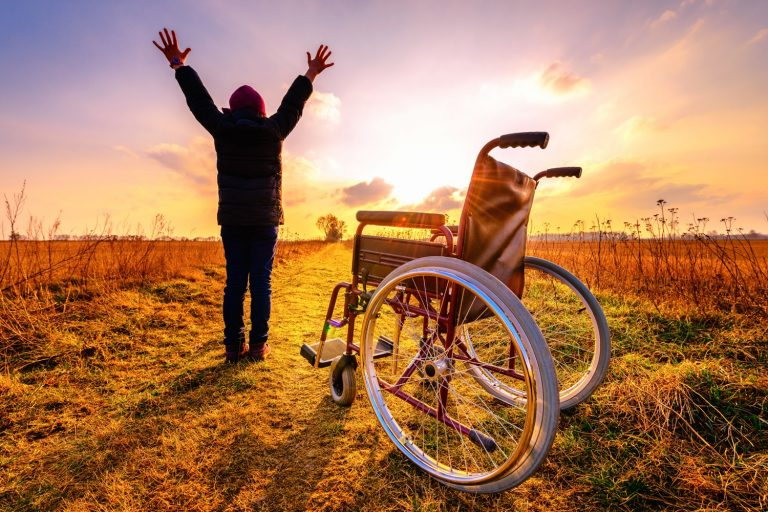

[image from](https://secure.kcm.org.au/realhelp/what-can-stop-jesus-healing-power/)

**Back in the boat, Jesus and the disciples recrossed the sea to Jesus’ hometown.They were hardly out of the boat when some men carried a paraplegic on a stretcher and set him down in front of them. Jesus, impressed by their bold belief, said to the paraplegic, “Cheer up, son! I forgive your sins.” Some religion scholars whispered, “Why, that’s blasphemy!**

**Jesus knew what they were thinking, and said, “Why this gossipy whispering? Which do you think is simpler: to say, ‘I forgive your sins,’ or, ‘Get up and walk’? Well, just so it’s clear that I’m the Son of Man and authorized to do either, or both….” At this he turned to the paraplegic and said, “Get up. Take your bed and go home.” And the man did it.The crowd was awestruck, amazed and pleased that God had authorized Jesus to work among them this way.**

# **June 7**, Matthew 9:9~13

- [Reading together](https://www.youtube.com/watch?v=2E7uTPMfFx8)

[figure not shown]

[image from](https://www.jw.org/en/library/books/jesus/ministry-in-galilee/matthew-tax-collector/)

**Passing along, Jesus saw a man at his work collecting taxes. His name was Matthew. Jesus said, “Come along with me.” Matthew stood up and followed him.**

**Later when Jesus was eating supper at Matthew’s house with his closed friends, a lot of disreputable characters came and join them. When the Pharisees saw him keeping this kind of company, they had a fit, and lit into Jesus’ followers. “What kind of example is this from your Teacher, acting cozy with crooks and riffraff?”**

**Jesus overhearing, shot back, “Who needs a doctor:the healthy or the sick? Go figure out what this Scripture means: ‘I’m after mercy, not religion.’ I’m here to invite outsiders, not coddle insiders.**

# **June 8**, Matthew 9:14~17

- [Reading together](https://www.youtube.com/watch?v=yfFc61ubhUU)
- 【Kingdom Come】

**A little later John’s followers approached, asking, “Why is it that we and the Pharisees rigorously discipline body and spirit by fasting, but your followers don’t?”**

**Jesus told them, “When you’re celebrating a wedding, you don’t skimp on the cake and wine. You feast. Later you may need to pull in your belt, but not now. No one throws cold water on a friendly bonfire. This is Kingdom Come!”**

**He went on, “No one cuts up a fine silk scarf to patch old work clothes; You want fabrics that match! And you don’t put your wine in cracked bottles”**

# **June 9**, Matthew 9:18~31

- [Reading together](https://www.youtube.com/watch?v=bVvqxd7eFIM)
- 【Just a Touch】
- 【Become Waht You Believe】

[figure not shown]

[image from](https://twitter.com/BibleInPics/status/478296938413305858/photo/1)

**As he finished saying this, a local official appeared bowed politely, and said, “My daughter has just now died. If you come and touch her, she will live.” Jesus got up and went with him, his disciples following along.**

**Just then a woman who had hemorrhaged for twelve years slipped in from behind and lightly touched his robe. She was thinking to herself, “If I can just put a finger on his robe, I’ll get well.” Jesus turned–caught her at it. Then he reassured her: “Courage, daughter! You took a risk of faith, and now you’re well.” The woman was well from then on.**

**By now they had arrived at the house of the town official, and pushed their way through the gossips looking for a story and the neighbors bringing in casseroles. Jesus was abrupt: “Clear out! This girl isn’t dead. She’s sleeping.” They him he didn’t know what he was talking about. But when Jesus had gotten rid of the crowd, he went in, took the girl’s hand, and pulled her to her feet–alive. The news was soon out, and traveled throughout the region.**

**As Jesus left the house, he was followed by two blind men crying out, “Mercy, Son of David! Mercy on us!” When Jesus got home, the blind men went in with him. Jesus said to them, “Do you really believe I can do this?” They said, “Why, Yes, Master!”**

**He touched their eyes and said, “Become what you believe.” It happened. They saw. Then Jesus became very stern. “Don’t let a soul know how this happened.” But they were hardly out the door before they started blabbing it to everyone they met.**

# **June 10**, Matthew 9:32~38

- [Reading together](https://www.youtube.com/watch?v=giuKhAijAAE)

[figure not shown]

[image from](https://www.jw.org/en/library/books/jesus/ministry-in-galilee/heals-demon-possessed-boy/)

**Right after that, as the blind men were leaving, a man who had been struck speechless by an evil spirit was brought to Jesus. As soon as Jesus threw the evil tormenting spirit out, the man talked away just as if he’d been talking all his life. The people were up on their feet applauding: “There’s never been anything like this in Israel!”**

**The Pharisees were left sputtering, “Hocus-pocus. It’s nothing but hocus-pocus. He’s probably made a pact with Devil.”**

**Then Jesus made a circuit of all the towns and villages. He taught in their meeting places, reported kingdom news, and healed their diseased bodies, healed their bruised and hurt lives. When he looked out over the crowds, his heart broke. So confused and aimless they were, like sheep with no shepherd. “What a huge harvest!” he said to his disciples. “How few workers! On your knees and pray for harvest hands!”**

# **June 11**, Matthew 10:1~15

- [Reading together](https://www.youtube.com/watch?v=eejtK0t-14M)
- 【The Twelve Harvest Hands】

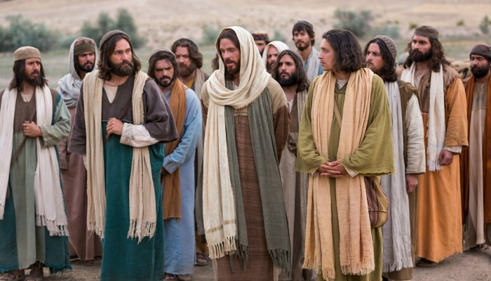

[image from](https://thirdhour.org/blog/faith/scripture/new-testament/original-apostles-deaths/)

**The prayer was no sooner prayed than it was answered. Jesus called twelve of his followers and sent them into the ripe fields. He gave them power to kick out the evil spirits and to tenderly care for the bruised and hurt lives. This is the list of the twelve he sent: Simon (they called him Peter, or “Rock”), Andrew, his brother, James, Zebedee’s son, John, his brother, Philip, Bartholomew, Thomas, Matthew, the tax man, James, son of Alphaeus, Thaddaeus, Simon, the Canaanite, Judas Iscariot (who later turned on him).**

**Jesus sent his twelve harvest hands out with this charge:** **“Don’t begin by traveling to some far-off place to convert unbelievers. And don’t try to be dramatic by tackling some public enemy. Go to the lost, confused people right here in neighborhood. Tell them that the kingdom is here. Bring health to the sick. Raise the dead. Touch the untouchables. Kick out the demons. You have been treated generously, so live generously.**

**“Don’t think you have to put on a fund-raising campaign before you start. You don’t need a lot of equipment. You are the equipment, and all you need to keep that going is three meals a day. Travel light.**

**“When you enter a town or village, don’t insist on staying in a luxury inn. Get a modest place with some modest people, and be content until you leave.**

**“When you knock on a door, be courteous in your greeting. If they welcome you, be gentle in your conversation. If they don’t welcome you, quietly withdraw. Don’t make a scene. Shrug your shoulders and be on your way. You can be sure that on Judgment Day they’ll be mighty sorry–but it’s no concern of yours now.**

# **June 12**

- Sunday

# **June 13**, Matthew 10:16~23

- [Reading together](https://www.youtube.com/watch?v=XplcbdpEteU)

**“Stay alert. This is hazardous work I’m assigning you. You’re going to be sheep running through a wolf pack, so don’t call attention to yourselves. Be as cunning as a snake, inoffensive as a dove.**

**“Don’t be naive. Some people will impugn your motives, others will smear your reputation–just because you believe in me. Don’t be upset when they haul you before the civil authorities. Without knowing it, they’ve done you–and me–a favor, given you a platform for preaching the kingdom news! And don’t worry about what you’ll say or how you’ll say it. The right words will be there; the Spirit of your Father will supply the words.**

**“When people realize it is the living God you are presenting and not some idol that makes them fell good, they are going to turn on you, even people in your own family. There is a great irony here,: proclaiming so much love, experiencing so much hate! But don’t quit. Don’t cave in. It is all well worth it in the end. It is not success you are after in such times but survival. Be survivors! Before you’ve run out of options, the Son of Man will have arrived.**

# **June 14**, Matthew 10:24~33

- [Reading together](https://www.youtube.com/watch?v=F19HxnPapOE)

**“A student doesn’t get a better desk than her teacher. A laborer doesn’t make more money than his boss. Be content–pleased, even–when you, my students, my harvest hands, get the same treatment I get. If they call me, the Master, ‘Dungface,’ what can the workers expect?**

**“Don’t be intimidated. Eventually everything is going to be out in the open, and everyone will know how things really are. So don’t hesitate to go public now.**

**“Don’t be bluffed into silence by the threats of bullies. There’s nothing they can do to your soul, your core being. Save your fear for God, who holds your entire life–body and soul–in his hands.**

**“What’s the price of a pet canary? Some loose change, right? And God cares what happens to it even more than you do. He pays even greater attention to you, down to the last detail–even the numbering the hairs on the head! So don’t intimidated by all this bully talk. You’re worth more than a million canaries.**

**“Stand up for me against world opinion and I’ll stand up for you before my Father in heaven. If you turn tail and run, do you think I’ll cover for you?**